# Reproducible Research: Peer Assessment 1

## Loading and preprocessing the data

```r
library(dplyr, warn.conflicts=F, quietly=T)
library(ggplot2, warn.conflicts=F, quietly=T)
```

1. Load the data (i.e. read.csv())

```r
d <- read.csv(unz("activity.zip","activity.csv"))
```

2. Process/transform the data (if necessary) into a format suitable for your analysis Not necessary at this point.

## What is mean total number of steps taken per day?

1. Make a histogram of the total number of steps taken each day

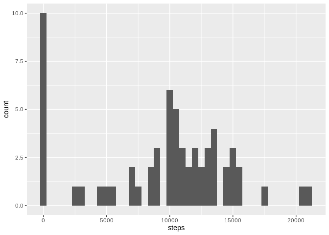

```r
daily_steps <- data.frame(summarize(group_by(d, date), steps=sum(steps, na.rm=T)))
p <- ggplot(data=daily_steps, aes(x=steps)) + geom_histogram(binwidth = 500)
print(p)
```

2. Calculate and report the mean and median total number of steps taken per day

```r
mean(daily_steps$steps)
```

```
## [1] 9354.23
```

```r
median(daily_steps$steps)
```

```
## [1] 10395
```

## What is the average daily activity pattern?

1. Make a time series plot (i.e. type = “l”) of the 5-minute interval (x-axis) and the average number of steps taken, averaged across all days (y-axis)

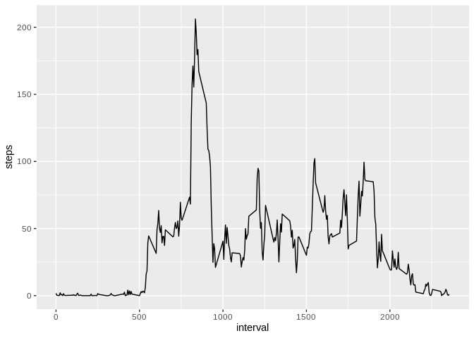

```r
interval_steps <- data.frame(summarize(group_by(d, interval), steps=mean(steps, na.rm=T)))
ggplot(data=interval_steps, aes(x=interval, y=steps)) + geom_line()
```

2. Which 5-minute interval, on average across all the days in the dataset, contains the maximum number of steps?

```r
interval_steps$interval[which.max(interval_steps$steps)]
```

```
## [1] 835
```

## Imputing missing values

1. Calculate and report the total number of missing values in the dataset (i.e. the total number of rows with NAs)

```r
sum(!complete.cases(d))
```

```
## [1] 2304
```

2. Devise a strategy for filling in all of the missing values in the dataset. The strategy does not need to be sophisticated. For example, you could use the mean/median for that day, or the mean for that 5-minute interval, etc.

I will use the average steps for that interval

3. Create a new dataset that is equal to the original dataset but with the missing data filled in.

```r
interval_to_index <- function(i){which(interval_steps$interval==i)}
imputed_d <- d
imputed_d$steps[is.na(d$steps)] <- round(interval_steps$steps[sapply(d$interval[is.na(d$steps)],interval_to_index)])
```

4. Make a histogram of the total number of steps taken each day and Calculate and report the mean and median total number of steps taken per day. Do these values differ from the estimates from the first part of the assignment? What is the impact of imputing missing data on the estimates of the total daily number of steps?

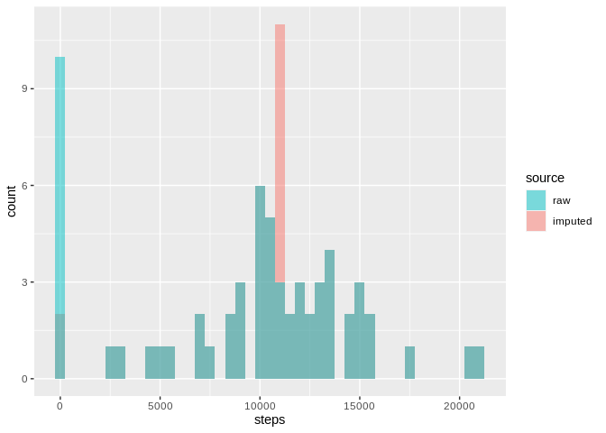

```r
daily_steps$source = "raw"
imputed_daily_steps <- data.frame(summarize(group_by(imputed_d, date), steps=sum(steps, na.rm=T)))
imputed_daily_steps$source = "imputed"
ds <- rbind(daily_steps, imputed_daily_steps)

ggplot(data=ds, aes(x=steps, fill=source)) + geom_histogram(binwidth = 500, alpha=0.5, position="identity") + guides(fill=guide_legend(reverse=T))
```

```r
data.frame(raw=c(mean(daily_steps$steps), median(daily_steps$steps)), imputed=c(mean(imputed_daily_steps$steps), median(imputed_daily_steps$steps)), row.names=c("Mean","Median"))
```

```
##             raw  imputed
## Mean    9354.23 10765.64
## Median 10395.00 10762.00
```

In the raw data, the missing values were treated as 0s, hence the mean was skewed down from the median. In the imputed data set, the mean and median match closely. Essentially, many zero-step days were shifted to 11000 steps.

## Are there differences in activity patterns between weekdays and weekends?

1. Create a new factor variable in the dataset with two levels – “weekday” and “weekend” indicating whether a given date is a weekday or weekend day.

```r
weekday <- weekdays(as.Date(imputed_d[,2])) %in% c('Monday','Tuesday','Wednesday','Thursday','Friday')
imputed_d$daytype <- factor(weekday, labels=c('Weekend','Weekday'))

interval_steps_daytype <- data.frame(summarize(group_by(imputed_d, interval, daytype), steps=mean(steps, na.rm=T)))
```

2. Make a panel plot containing a time series plot (i.e. type = “l”) of the 5-minute interval (x-axis) and the average number of steps taken, averaged across all weekday days or weekend days (y-axis). The plot should look something like the following, which was created using simulated data:

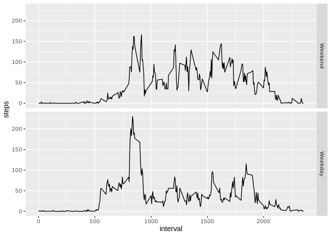

```r
ggplot(data=interval_steps_daytype, aes(x=interval, y=steps)) + geom_path() + facet_grid(daytype ~ .)
```